# From Large Spatiotemporal Data to Urban Insights

## Exploratory Data Analysis

We now have a clean, lightweight, borough-level daily dataset spanning 19 years. Let's explore it.

### Overview and Basic Statistics

```python
# Load the combined dataset (or continue from above)
df = pd.read_parquet(OUTPUT_DIR / 'ldn_nrr95p_all_years.parquet')

# Ensure time is datetime
df['time'] = pd.to_datetime(df['time'])

# Add useful time columns
df['year'] = df['time'].dt.year
df['month'] = df['time'].dt.month
df['day_of_year'] = df['time'].dt.dayofyear

# Load borough geometry for maps later
borough_geo = gpd.read_file(GEO_DIR / 'borough_lookup.gpkg')

print(f"Shape: {df.shape}")
df.describe()
```

```
Shape: (534380, 6)
```

|  | time | nrr95p | year | month | day_of_year |
| --- | --- | --- | --- | --- | --- |
| count | 534380 | 534380.0000 | 534380.0000 | 534380.0000 | 534380.0000 |
| mean | 2009-07-01 12:00:00.000000256 | 0.1177 | 2008.9993 | 6.5228 | 183.1318 |
| min | 2000-01-01 00:00:00 | 0.0000 | 2000.0000 | 1.0000 | 1.0000 |
| 25% | 2004-09-30 18:00:00 | 0.0000 | 2004.0000 | 4.0000 | 92.0000 |
| 50% | 2009-07-01 12:00:00 | 0.0047 | 2009.0000 | 7.0000 | 183.0000 |
| 75% | 2014-04-01 06:00:00 | 0.1200 | 2014.0000 | 10.0000 | 274.0000 |
| max | 2018-12-31 00:00:00 | 4.9264 | 2018.0000 | 12.0000 | 366.0000 |
| std | NaN | 0.2481 | 5.4774 | 3.4488 | 105.4426 |

### Understanding the Data: Extreme Events vs Background Noise

A key feature of extreme precipitation data: **most days are not extreme.** The `nrr95p` variable is 0 on dry days and only exceeds 1.0 when precipitation actually surpasses the 95th percentile threshold. This means averages will be dominated by many near-zero days.

For London (which is famously wet), this means simple averages across boroughs will look very similar. We need to focus on **the tail of the distribution** — the extreme days — to see meaningful spatial and temporal patterns.

```python
# What fraction of days are "extreme" (nrr95p > 1)?
total_days = len(df)
extreme_days_count = (df['nrr95p'] > 1).sum()
wet_days_count = (df['nrr95p'] > 0).sum()

print(f"Total borough-days: {total_days:,}")
print(f"Days with any precipitation signal (nrr95p > 0): {wet_days_count:,} ({wet_days_count/total_days*100:.1f}%)")
print(f"Extreme days (nrr95p > 1): {extreme_days_count:,} ({extreme_days_count/total_days*100:.1f}%)")
```

```
Total borough-days: 534,380
Days with any precipitation signal (nrr95p > 0): 375,571 (70.3%)
Extreme days (nrr95p > 1): 8,330 (1.6%)
```

```python
# Count extreme days (nrr95p > 1) per borough per year
threshold = 1.0

extreme_by_year = (
    df[df['nrr95p'] > threshold]
    .groupby(['name', 'year'])
    .size()
    .reset_index(name='extreme_days')
)

# City-wide: average across boroughs per year
city_extreme = extreme_by_year.groupby('year')['extreme_days'].mean()
```

### When Do Extreme Events Happen?

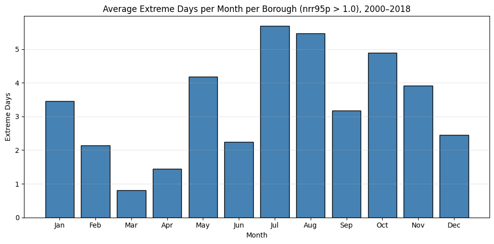

```python
# Count extreme days by month (aggregated over all years and boroughs)
extreme_by_month = (
    df[df['nrr95p'] > threshold]
    .groupby('month')
    .size()
)

# Normalise: total extreme occurrences per month, divided by number of years and boroughs
n_years = df['year'].nunique()
n_boroughs = df['name'].nunique()
extreme_monthly_rate = extreme_by_month / (n_years * n_boroughs)

month_labels = ['Jan','Feb','Mar','Apr','May','Jun','Jul','Aug','Sep','Oct','Nov','Dec']

fig, ax = plt.subplots(figsize=(10, 5))
ax.bar(range(1, 13), extreme_monthly_rate, color='steelblue', edgecolor='black')
ax.set_xticks(range(1, 13))
ax.set_xticklabels(month_labels)
ax.set_title(f'Average Extreme Days per Month per Borough (nrr95p > {threshold}), 2000–2018')
ax.set_xlabel('Month')
ax.set_ylabel('Extreme Days')
ax.grid(True, axis='y', alpha=0.3)
plt.tight_layout()
plt.show()
```

### Extreme Event Frequency by Year × Month

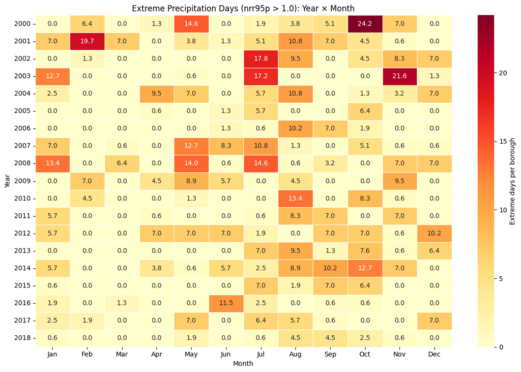

```python
# Count extreme days per year-month (across all boroughs)
extreme_ym = (
    df[df['nrr95p'] > threshold]
    .groupby(['year', 'month'])
    .size()
    .unstack(fill_value=0)
)
# Normalise by number of boroughs to get "average extreme days per borough"
extreme_ym = extreme_ym / n_boroughs
extreme_ym.columns = month_labels

fig, ax = plt.subplots(figsize=(12, 8))
sns.heatmap(extreme_ym, cmap='YlOrRd', annot=True, fmt='.1f', linewidths=0.5, ax=ax,
            cbar_kws={'label': 'Extreme days per borough'})
ax.set_title(f'Extreme Precipitation Days (nrr95p > {threshold}): Year × Month')
ax.set_ylabel('Year')
ax.set_xlabel('Month')
plt.tight_layout()
plt.show()
```

### Which Boroughs Have the Most Intense Events?

```python
# Instead of mean (which is dominated by zeros), look at:
# - Total extreme days
# - Mean intensity on extreme days
# - Maximum single-day event

borough_extreme_stats = (
    df[df['nrr95p'] > threshold]
    .groupby('name')
    .agg(
        total_extreme_days=('nrr95p', 'count'),
        mean_intensity=('nrr95p', 'mean'),
        max_event=('nrr95p', 'max'),
        p90_intensity=('nrr95p', lambda x: x.quantile(0.90))
    )
    .round(3)
    .sort_values('max_event', ascending=False)
)

borough_extreme_stats
```

| name | total_extreme_days | mean_intensity | max_event | p90_intensity |
| --- | --- | --- | --- | --- |
| City of London | 798 | 1.4140 | 4.9260 | 1.9750 |
| Lambeth | 728 | 1.3850 | 4.8730 | 1.8950 |
| Hackney | 756 | 1.3980 | 4.4380 | 1.9230 |
| Westminster | 756 | 1.3570 | 4.3690 | 1.8860 |
| Tower Hamlets | 770 | 1.4370 | 4.1930 | 1.9560 |
| Islington | 763 | 1.3830 | 3.9890 | 1.9730 |
| Newham | 770 | 1.3920 | 3.7330 | 1.9600 |
| Southwark | 735 | 1.3980 | 3.7220 | 1.9450 |
| Haringey | 770 | 1.3690 | 3.3710 | 1.7540 |
| Camden | 728 | 1.3930 | 3.3160 | 1.9160 |
| Lewisham | 756 | 1.3830 | 2.6150 | 1.9490 |

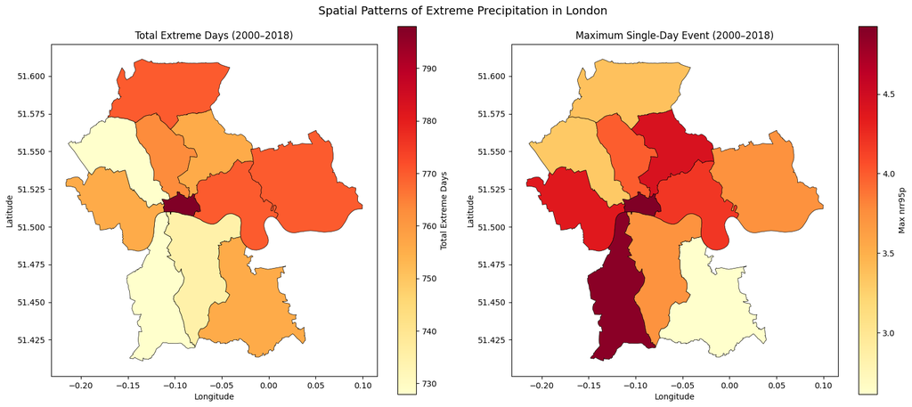

```python
# Map: maximum single-day extreme precipitation per borough (2000–2018)
map_data = borough_geo.merge(borough_extreme_stats.reset_index(), on='name', how='left')

fig, axes = plt.subplots(1, 2, figsize=(16, 7))

map_data.plot(ax=axes[0], column='total_extreme_days', cmap='YlOrRd',
              edgecolor='black', linewidth=0.5, legend=True,
              legend_kwds={'label': 'Total Extreme Days'})
axes[0].set_title('Total Extreme Days (2000–2018)')

map_data.plot(ax=axes[1], column='max_event', cmap='YlOrRd',
              edgecolor='black', linewidth=0.5, legend=True,
              legend_kwds={'label': 'Max nrr95p'})
axes[1].set_title('Maximum Single-Day Event (2000–2018)')

for ax in axes:
    ax.set_xlabel('Longitude')
    ax.set_ylabel('Latitude')

plt.suptitle('Spatial Patterns of Extreme Precipitation in London', fontsize=14)
plt.tight_layout()
plt.show()
```